# Peer Assessment for Regressio Models Coursera.org Course

Aleksandr Salynskii

23 Aug 2015

## Introduction

Here we’ll analyse the relationship between the type of the transmission and MPG(miles per galon) characteristics of the different cars.  
First of all we would use the `mtcars` dataset.

```r
data(mtcars)
```

The `mtcars` dataset contains from 32 automobiles (1973-74 models) on 11 variables.  
`mpg` - Miles/(US) gallon  
`cyl` - Number of cylinders  
`disp` - Displacement (cu.in.)  
`hp` - Gross horsepower  
`drat` - Rear axle ratio  
`wt` - Weight (lb/1000)  
`qsec` - 1/4 mile time  
`vs` - V/S  
`am` - Transmission (0 = automatic, 1 = manual)  
`gear` - Number of forward gears  
`carb` - Number of carburetors

## Analysis

Here we can see the simple distribution of the MPG with type of transmission as the factor.

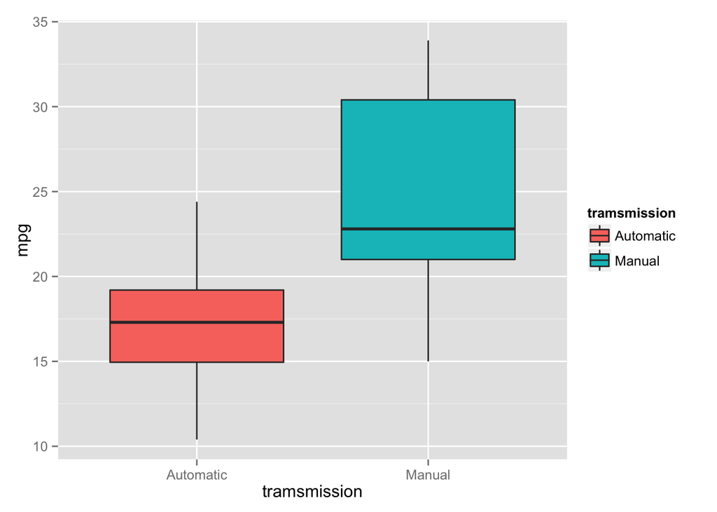

```r
library(ggplot2)
library(dplyr)
mtcarsMod <- mutate(mtcars, tramsmission = ifelse(am == 0, "Automatic", "Manual"))
mtcarsMod$tramsmission <- as.factor(mtcarsMod$tramsmission)
ggplot(data = mtcarsMod, aes(x = tramsmission, y = mpg, fill = tramsmission)) +
   geom_boxplot()
```

Here we can see, that the mean of the MPG value is higher in cars with manual transmission instead of automatic.  
Lets fit the linear model to prove it.

```r
fit <- lm(mpg ~ am, data = mtcarsMod)
summary(fit)
```

```
##
## Call:
## lm(formula = mpg ~ am, data = mtcarsMod)
##
## Residuals:
##     Min      1Q  Median      3Q     Max
## -9.3923 -3.0923 -0.2974  3.2439  9.5077
##
## Coefficients:
##             Estimate Std. Error t value Pr(>|t|)
## (Intercept)   17.147      1.125  15.247 1.13e-15 ***
## am             7.245      1.764   4.106 0.000285 ***
## ---
## Signif. codes:  0 '***' 0.001 '**' 0.01 '*' 0.05 '.' 0.1 ' ' 1
##
## Residual standard error: 4.902 on 30 degrees of freedom
## Multiple R-squared:  0.3598, Adjusted R-squared:  0.3385
## F-statistic: 16.86 on 1 and 30 DF,  p-value: 0.000285
```

Here we can see, that the cars with manual transmission has additional **7.245** mpg(the value of the Estimate is adding to the mpg result if the transmission type is manual), also we can see, that P value is less than **0.05** so the type of the transmission is significant predictor in this model.  
Now we’ll fit some additional models to prove it.

```r
round(cor(mtcars), 3)
```

```
##         mpg    cyl   disp     hp   drat     wt   qsec     vs     am   gear
## mpg   1.000 -0.852 -0.848 -0.776  0.681 -0.868  0.419  0.664  0.600  0.480
## cyl  -0.852  1.000  0.902  0.832 -0.700  0.782 -0.591 -0.811 -0.523 -0.493
## disp -0.848  0.902  1.000  0.791 -0.710  0.888 -0.434 -0.710 -0.591 -0.556
## hp   -0.776  0.832  0.791  1.000 -0.449  0.659 -0.708 -0.723 -0.243 -0.126
## drat  0.681 -0.700 -0.710 -0.449  1.000 -0.712  0.091  0.440  0.713  0.700
## wt   -0.868  0.782  0.888  0.659 -0.712  1.000 -0.175 -0.555 -0.692 -0.583
## qsec  0.419 -0.591 -0.434 -0.708  0.091 -0.175  1.000  0.745 -0.230 -0.213
## vs    0.664 -0.811 -0.710 -0.723  0.440 -0.555  0.745  1.000  0.168  0.206
## am    0.600 -0.523 -0.591 -0.243  0.713 -0.692 -0.230  0.168  1.000  0.794
## gear  0.480 -0.493 -0.556 -0.126  0.700 -0.583 -0.213  0.206  0.794  1.000
## carb -0.551  0.527  0.395  0.750 -0.091  0.428 -0.656 -0.570  0.058  0.274
##        carb
## mpg  -0.551
## cyl   0.527
## disp  0.395
## hp    0.750
## drat -0.091
## wt    0.428
## qsec -0.656
## vs   -0.570
## am    0.058
## gear  0.274
## carb  1.000
```

As we know the corr value means the relationship between two values, so for good model we need to use the variables with **minimum** absolute value of the corr index. So as we see in the upper table, the **am** variable has the smallest corr indexes with **vs, qsec, hp, carb** values, so lest try to fit the model with this predictors and compare the result with previous fit.

```r
fit2 <- lm(mpg ~ hp + qsec + vs + am + carb, mtcarsMod)
summary(fit2)
```

```
##
## Call:
## lm(formula = mpg ~ hp + qsec + vs + am + carb, data = mtcarsMod)
##
## Residuals:
##     Min      1Q  Median      3Q     Max
## -5.3405 -1.8046  0.1023  1.8289  5.1549
##
## Coefficients:
##             Estimate Std. Error t value Pr(>|t|)
## (Intercept) 25.74532   12.03044   2.140 0.041906 *
## hp          -0.03386    0.01587  -2.134 0.042452 *
## qsec        -0.12784    0.60648  -0.211 0.834695
## vs           2.75995    1.77850   1.552 0.132789
## am           5.66570    1.44153   3.930 0.000561 ***
## carb        -0.68094    0.50958  -1.336 0.193034
## ---
## Signif. codes:  0 '***' 0.001 '**' 0.01 '*' 0.05 '.' 0.1 ' ' 1
##
## Residual standard error: 2.805 on 26 degrees of freedom
## Multiple R-squared:  0.8183, Adjusted R-squared:  0.7833
## F-statistic: 23.42 on 5 and 26 DF,  p-value: 7.222e-09
```

Here we can see, that in this model the most significant predictor is **am**, the value of the transmission in this model has the P value smallest P value of **0.00056**, also the **hp** variable seems to be significant because of it’s **0.0424** P value. But the R-squared value is much higher than in the model with only transmission type as the predictor.  
Also for the complete analysis we need to fit the full model, with all variables from number of cylinders(`cyl`) to the number of carburetors(`carb`) as the predictors of the outcome value of `mpg`.

```r
fitFull <- lm(mpg ~ ., mtcars)
summary(fitFull)
```

```
##
## Call:
## lm(formula = mpg ~ ., data = mtcars)
##
## Residuals:
##     Min      1Q  Median      3Q     Max
## -3.4506 -1.6044 -0.1196  1.2193  4.6271
##
## Coefficients:
##             Estimate Std. Error t value Pr(>|t|)
## (Intercept) 12.30337   18.71788   0.657   0.5181
## cyl         -0.11144    1.04502  -0.107   0.9161
## disp         0.01334    0.01786   0.747   0.4635
## hp          -0.02148    0.02177  -0.987   0.3350
## drat         0.78711    1.63537   0.481   0.6353
## wt          -3.71530    1.89441  -1.961   0.0633 .
## qsec         0.82104    0.73084   1.123   0.2739
## vs           0.31776    2.10451   0.151   0.8814
## am           2.52023    2.05665   1.225   0.2340
## gear         0.65541    1.49326   0.439   0.6652
## carb        -0.19942    0.82875  -0.241   0.8122
## ---
## Signif. codes:  0 '***' 0.001 '**' 0.01 '*' 0.05 '.' 0.1 ' ' 1
##
## Residual standard error: 2.65 on 21 degrees of freedom
## Multiple R-squared:  0.869,  Adjusted R-squared:  0.8066
## F-statistic: 13.93 on 10 and 21 DF,  p-value: 3.793e-07
```

The summary of the full model tells us, that there is only one variable hos nearly significant value of the P value, but the R-squared value is much greater than the one we see in the model with only `am` as predictor.

```r
summary(lm(mpg ~ cyl, mtcars))
```

```
##
## Call:
## lm(formula = mpg ~ cyl, data = mtcars)
##
## Residuals:
##     Min      1Q  Median      3Q     Max
## -4.9814 -2.1185  0.2217  1.0717  7.5186
##
## Coefficients:
##             Estimate Std. Error t value Pr(>|t|)
## (Intercept)  37.8846     2.0738   18.27  < 2e-16 ***
## cyl          -2.8758     0.3224   -8.92 6.11e-10 ***
## ---
## Signif. codes:  0 '***' 0.001 '**' 0.01 '*' 0.05 '.' 0.1 ' ' 1
##
## Residual standard error: 3.206 on 30 degrees of freedom
## Multiple R-squared:  0.7262, Adjusted R-squared:  0.7171
## F-statistic: 79.56 on 1 and 30 DF,  p-value: 6.113e-10
```

```r
summary(lm(mpg ~ wt, mtcars))
```

```
##
## Call:
## lm(formula = mpg ~ wt, data = mtcars)
##
## Residuals:
##     Min      1Q  Median      3Q     Max
## -4.5432 -2.3647 -0.1252  1.4096  6.8727
##
## Coefficients:
##             Estimate Std. Error t value Pr(>|t|)
## (Intercept)  37.2851     1.8776  19.858  < 2e-16 ***
## wt           -5.3445     0.5591  -9.559 1.29e-10 ***
## ---
## Signif. codes:  0 '***' 0.001 '**' 0.01 '*' 0.05 '.' 0.1 ' ' 1
##
## Residual standard error: 3.046 on 30 degrees of freedom
## Multiple R-squared:  0.7528, Adjusted R-squared:  0.7446
## F-statistic: 91.38 on 1 and 30 DF,  p-value: 1.294e-10
```

```r
summary(lm(mpg ~ hp, mtcars))
```

```
##
## Call:
## lm(formula = mpg ~ hp, data = mtcars)
##
## Residuals:
##     Min      1Q  Median      3Q     Max
## -5.7121 -2.1122 -0.8854  1.5819  8.2360
##
## Coefficients:
##             Estimate Std. Error t value Pr(>|t|)
## (Intercept) 30.09886    1.63392  18.421  < 2e-16 ***
## hp          -0.06823    0.01012  -6.742 1.79e-07 ***
## ---
## Signif. codes:  0 '***' 0.001 '**' 0.01 '*' 0.05 '.' 0.1 ' ' 1
##
## Residual standard error: 3.863 on 30 degrees of freedom
## Multiple R-squared:  0.6024, Adjusted R-squared:  0.5892
## F-statistic: 45.46 on 1 and 30 DF,  p-value: 1.788e-07
```

```r
summary(lm(mpg ~ qsec, mtcars))
```

```
##
## Call:
## lm(formula = mpg ~ qsec, data = mtcars)
##
## Residuals:
##     Min      1Q  Median      3Q     Max
## -9.8760 -3.4539 -0.7203  2.2774 11.6491
##
## Coefficients:
##             Estimate Std. Error t value Pr(>|t|)
## (Intercept)  -5.1140    10.0295  -0.510   0.6139
## qsec          1.4121     0.5592   2.525   0.0171 *
## ---
## Signif. codes:  0 '***' 0.001 '**' 0.01 '*' 0.05 '.' 0.1 ' ' 1
##
## Residual standard error: 5.564 on 30 degrees of freedom
## Multiple R-squared:  0.1753, Adjusted R-squared:  0.1478
## F-statistic: 6.377 on 1 and 30 DF,  p-value: 0.01708
```

```r
summary(lm(mpg ~ carb, mtcars))
```

```
##
## Call:
## lm(formula = mpg ~ carb, data = mtcars)
##
## Residuals:
##    Min     1Q Median     3Q    Max
## -7.250 -3.316 -1.433  3.384 10.083
##
## Coefficients:
##             Estimate Std. Error t value Pr(>|t|)
## (Intercept)  25.8723     1.8368  14.085 9.22e-15 ***
## carb         -2.0557     0.5685  -3.616  0.00108 **
## ---
## Signif. codes:  0 '***' 0.001 '**' 0.01 '*' 0.05 '.' 0.1 ' ' 1
##
## Residual standard error: 5.113 on 30 degrees of freedom
## Multiple R-squared:  0.3035, Adjusted R-squared:  0.2803
## F-statistic: 13.07 on 1 and 30 DF,  p-value: 0.001084
```

## Conclusion

As we can see from the analysis part of this work, the transmission factor is significant factor for prediction of the `mpg` value of the car.(Very small P value of the coefficient in the model and the model P value at all.) Also we can say, that the manual transmission add about **7.245** to the `mpg` of the car. But out boxplot tell’s us, that only the prediction of the cars with automatic transmission’ll be effective instead of manual.